# Parteien und Wahlen in Deutschland

Holger Doering – doering@uni-bremen.de

```r
library(tidyverse)
library(readr)
library(haven)
library(knitr)
```

**Literatur Grundlage**

- Saalfeld, Thomas. 2007. Parteien und Wahlen. Nomos.
- Seiten 88-119

# GLES Wahlstudie

German Longitudinal Election Study (GLES) 2017 – gles.eu

```r
gles_raw <- haven::read_dta("daten/gles-2017/ZA6801_v2-0-0.dta", encoding = "latin1")

gles <-
  gles_raw %>%
  select(
    erststimme = q19aa,
    zweitstimme = q19ba,
    links_rechts = q32
  ) %>%
  mutate(
    links_rechts = ifelse(links_rechts < 0, NA, links_rechts)
    )
```

## Q-19: BTW Erst-/Zweitstimme

*Fragetext:* Bei der Bundestagswahl konnten Sie ja zwei Stimmen vergeben. Die Erststimme für einen Kandidaten aus Ihrem Wahlkreis, die Zweitstimme für eine Partei. Hier ist ein Musterstimmzettel, ähnlich wie Sie ihn bei der Bundestagswahl erhalten haben. Wie haben Sie auf Ihrem Stimmzettel angekreuzt? Bitte nennen Sie mir jeweils die Kennziffer für Ihre Erst- und Zweitstimme.

```r
partei <-
  gles %>%
  select(-links_rechts) %>%
  filter(erststimme > 0, zweitstimme > 0) %>%
  mutate(
    erststimme = as_factor(erststimme),
    zweitstimme = as_factor(zweitstimme)
    )

partei %>%
  count(zweitstimme) %>%
  mutate(anteil = round(100*n/sum(n), 1)) %>%
  kable()
```

| zweitstimme | n | anteil |
| --- | --- | --- |
| CDU/CSU | 502 | 29.8 |
| SPD | 336 | 20.0 |
| FDP | 199 | 11.8 |
| GRUENE | 224 | 13.3 |
| DIE LINKE | 188 | 11.2 |
| AfD | 162 | 9.6 |
| andere Partei | 72 | 4.3 |

```r
partei %>%
  count(erststimme) %>%
  mutate(anteil = round(100*n/sum(n), 1)) %>%
  kable()
```

| erststimme | n | anteil |
| --- | --- | --- |
| CDU/CSU | 592 | 35.2 |
| SPD | 425 | 25.3 |
| FDP | 136 | 8.1 |
| GRUENE | 163 | 9.7 |
| DIE LINKE | 166 | 9.9 |
| AfD | 148 | 8.8 |
| andere Partei | 53 | 3.1 |

#### Kreuztabelle: Zweit- und Erststimme

```r
partei %>%
  count(zweitstimme, erststimme) %>%
  spread(erststimme, n) %>%
  kable()
```

| zweitstimme | CDU/CSU | SPD | FDP | GRUENE | DIE LINKE | AfD | andere Partei |
| --- | --- | --- | --- | --- | --- | --- | --- |
| CDU/CSU | 426 | 23 | 27 | 11 | 5 | 5 | 5 |
| SPD | 29 | 270 | 4 | 16 | 11 | 3 | 3 |
| FDP | 76 | 18 | 91 | 4 | 2 | 3 | 5 |
| GRUENE | 30 | 67 | NA | 109 | 13 | NA | 5 |
| DIE LINKE | 8 | 33 | 3 | 14 | 120 | 5 | 5 |
| AfD | 14 | 3 | 9 | NA | 4 | 129 | 3 |
| andere Partei | 9 | 11 | 2 | 9 | 11 | 3 | 27 |

## Q-32: Links-Rechts-Selbsteinstufung

*siehe auch Saalfeld (2007, 92) – Tabelle 2.6*

*Fragetext:* Und wie ist das mit Ihnen selbst? Wo würden Sie sich auf der Skala von 1 bis 11 einordnen?

```r
gles %>%
  filter(! is.na(links_rechts)) %>%
  count(links_rechts) %>%
  mutate(anteil = round(100*n/sum(n), 1),
         kumuliert = cumsum(anteil)) %>%
  kable()
```

| links_rechts | n | anteil | kumuliert |
| --- | --- | --- | --- |
| 1 | 53 | 2.7 | 2.7 |
| 2 | 105 | 5.3 | 8.0 |
| 3 | 263 | 13.4 | 21.4 |
| 4 | 249 | 12.7 | 34.1 |
| 5 | 354 | 18.0 | 52.1 |
| 6 | 552 | 28.1 | 80.2 |
| 7 | 184 | 9.4 | 89.6 |
| 8 | 118 | 6.0 | 95.6 |
| 9 | 50 | 2.5 | 98.1 |
| 10 | 13 | 0.7 | 98.8 |
| 11 | 23 | 1.2 | 100.0 |

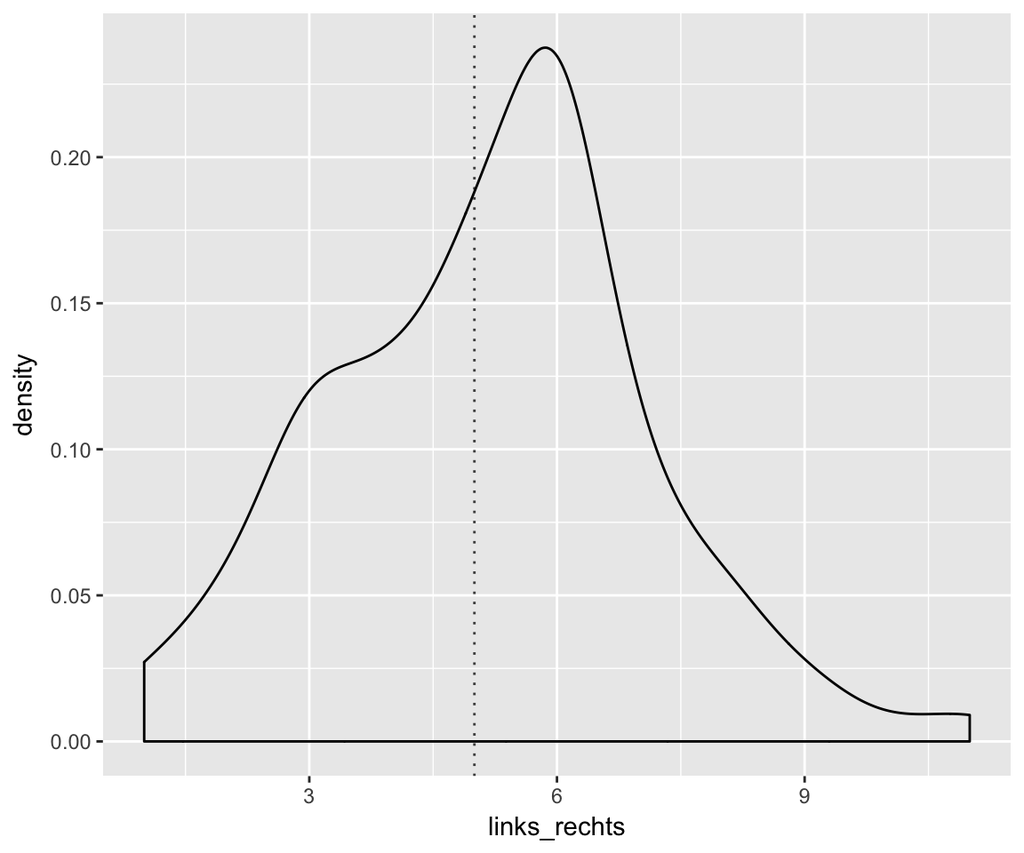

```r
ggplot(gles, aes(links_rechts)) +
  geom_vline(aes(xintercept=median(links_rechts, na.rm = TRUE)),
             colour = "grey30", linetype="dotted") +
  geom_density(adjust=2)
```

**Q-31:** Links-Rechts-Einstufung Parteien

**Fragetext:** In der Politik reden die Leute häufig von “links” und “rechts”. Wenn Sie diese Skala von 1 bis 11 benutzen, wo würden Sie die folgenden Parteien einordnen, wenn 1 “links” und 11 “rechts” ist?

Items: (A) CDU; (B) CSU; (C) SPD; (D) DIE LINKE; (E) GRÜNE; (F) FDP; (G) AfD

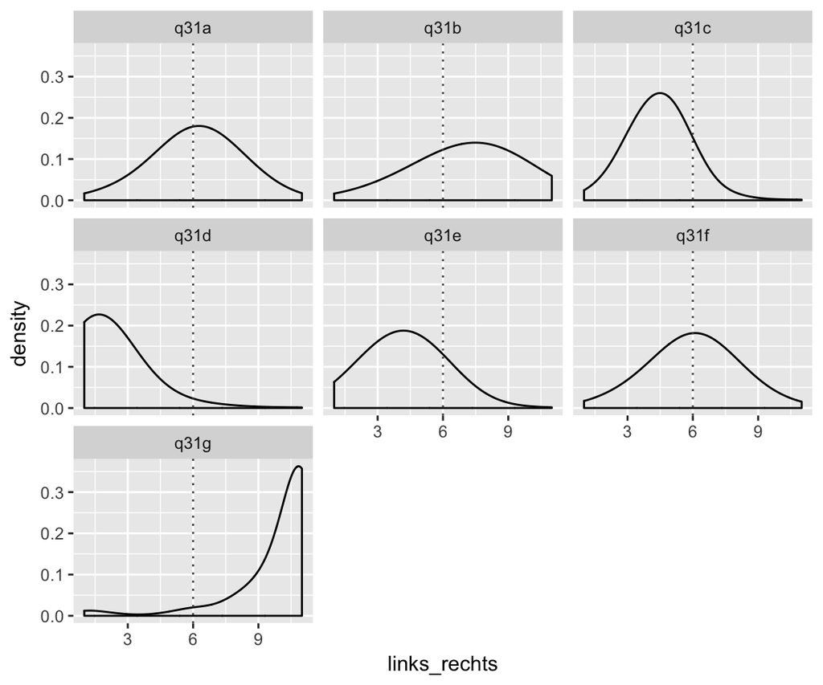

```r
lr_partei <-
  gles_raw %>%
  select(starts_with("q31")) %>%
  gather(partei, links_rechts) %>%
  filter(links_rechts >= 0)

ggplot(lr_partei, aes(links_rechts)) +
  geom_density(adjust=5) +
  geom_vline(aes(xintercept=median(links_rechts, na.rm = TRUE)),
             colour = "grey30", linetype="dotted") +
  facet_wrap(~partei)
```

# Manifesto Daten

*siehe auch Saalfeld (2007, 96) – Tabelle 2.8*

https://manifesto-project.wzb.eu/

**rile:** Right-left position of party

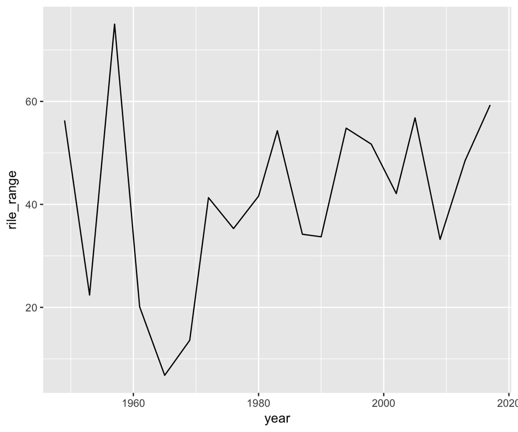

```r
manifesto_raw <- read_csv("daten/manifesto-2017/MPDataset_MPDS2017b.csv")

ma_deu <-
  manifesto_raw %>%
  filter(countryname == "Germany") %>%
  mutate(
    pervote = round(pervote, 1),
    year = date %/% 100,
    rile = round(rile, 1)
    ) %>%
  select(year, partyname, pervote, rile)

deu_rile <-
  ma_deu %>%
  group_by(year) %>%
  summarise(rile_range = max(rile) - min(rile))

ggplot(deu_rile, aes(year, rile_range)) + geom_line()
```

```r
kable(ma_deu)
```

| year | partyname | pervote | rile |
| --- | --- | --- | --- |
| 1949 | Communist Party of Germany | 5.7 | -10.2 |
| 1949 | Social Democratic Party of Germany | 29.2 | -18.4 |
| 1949 | Free Democratic Party | 11.9 | 6.5 |
| 1949 | Christian Democratic Union/Christian Social Union | 31.0 | -11.6 |
| 1949 | Centre Party | 3.1 | -21.7 |
| 1949 | German Party | 4.0 | 28.6 |
| 1949 | Economic Reconstruction League | 2.9 | -24.7 |
| 1949 | German Reich Party | 1.8 | 20.0 |
| 1949 | Bavarian Party | 4.2 | 28.6 |
| 1949 | South Schleswig Voters’ Union | 0.3 | 31.6 |
| 1953 | Social Democratic Party of Germany | 28.8 | -23.5 |
| 1953 | Free Democratic Party | 9.5 | -1.1 |
| 1953 | Christian Democratic Union/Christian Social Union | 45.2 | -6.6 |
| 1953 | Centre Party | 0.8 | -10.0 |
| 1953 | German Party | 3.3 | -15.5 |
| 1953 | Refugee Party | 5.9 | -13.3 |
| 1957 | Social Democratic Party of Germany | 31.8 | -25.0 |
| 1957 | Free Democratic Party | 7.7 | 0.0 |
| 1957 | Christian Democratic Union/Christian Social Union | 50.2 | 50.0 |
| 1957 | German Party | 3.4 | -20.0 |
| 1961 | Social Democratic Party of Germany | 36.2 | -2.9 |
| 1961 | Free Democratic Party | 12.8 | -17.8 |
| 1961 | Christian Democratic Union/Christian Social Union | 45.3 | 2.3 |
| 1965 | Social Democratic Party of Germany | 39.3 | -5.9 |
| 1965 | Free Democratic Party | 9.5 | 0.9 |
| 1965 | Christian Democratic Union/Christian Social Union | 47.6 | -1.6 |
| 1969 | Social Democratic Party of Germany | 42.7 | -10.4 |
| 1969 | Free Democratic Party | 5.8 | -18.7 |
| 1969 | Christian Democratic Union/Christian Social Union | 46.1 | -5.1 |
| 1972 | Social Democratic Party of Germany | 45.9 | -14.4 |

[output cut: 59 more lines]